# Лабораторная №3

Сетевые технологии - Жибицкая Е.Д.

Российский университет дружбы народов, Москва, Россия

# Цель

## Цель работы

- Знакомство с Wireshark, изучение с его помощью кадров Ethernet, анализ PDU протоколов транспортного и прикладного уровней стека TCP/IP

# Ход работы

## Информация об устройстве

[figure not shown]

ipconfig

[figure not shown]

ipconfig /all

## Информация об устройстве

[figure not shown]

Содержимое кэша сопоставителя DNS

[figure not shown]

MAC-адрес

## МАС-адрес

MAC-адрес 38-D5-7A-F6-60-DD

OUI (идентификатор производителя): 38-D5-7A

Идентификатор сетевого интерфейса(уникальная часть: F6-60-DD

Тип адреса:

Индивидуальный (Unicast): Младший бит первого байта (38 -> 00111000) равен 0.

Глобально администрируемый (UAA): Второй младший бит первого байта равен 0.

## Установка пакетов

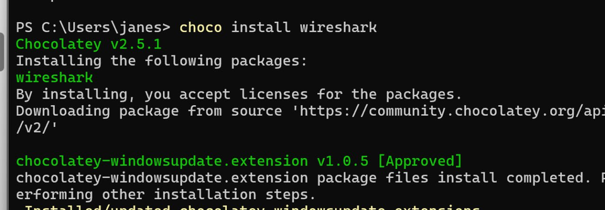

Установка wireshark

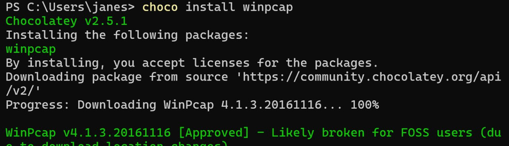

Установка winpcap

## Wireshark

Далее запускаем Wireshark, выбираем активный на устройстве интерфейс и смотрим, что начался захват трафика

[figure not shown]

Запуск программы

## Определение данных

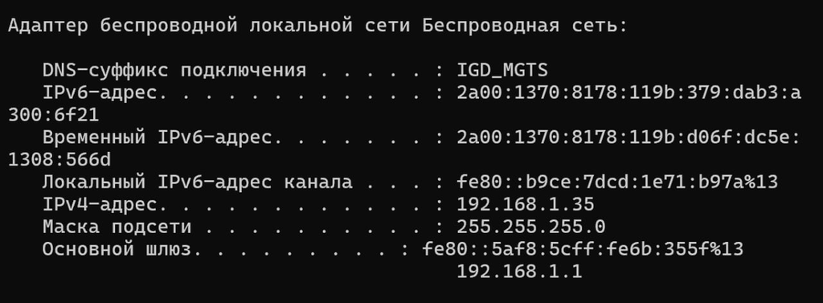

ipconfig

Далее командой ipconfig определим IP-адрес устройства и шлюз по умолчанию

## Пакеты

[figure not shown]

Команда ping

[figure not shown]

Пакеты arp or icm

## Эхо-запрос и эхо-ответ ICMP

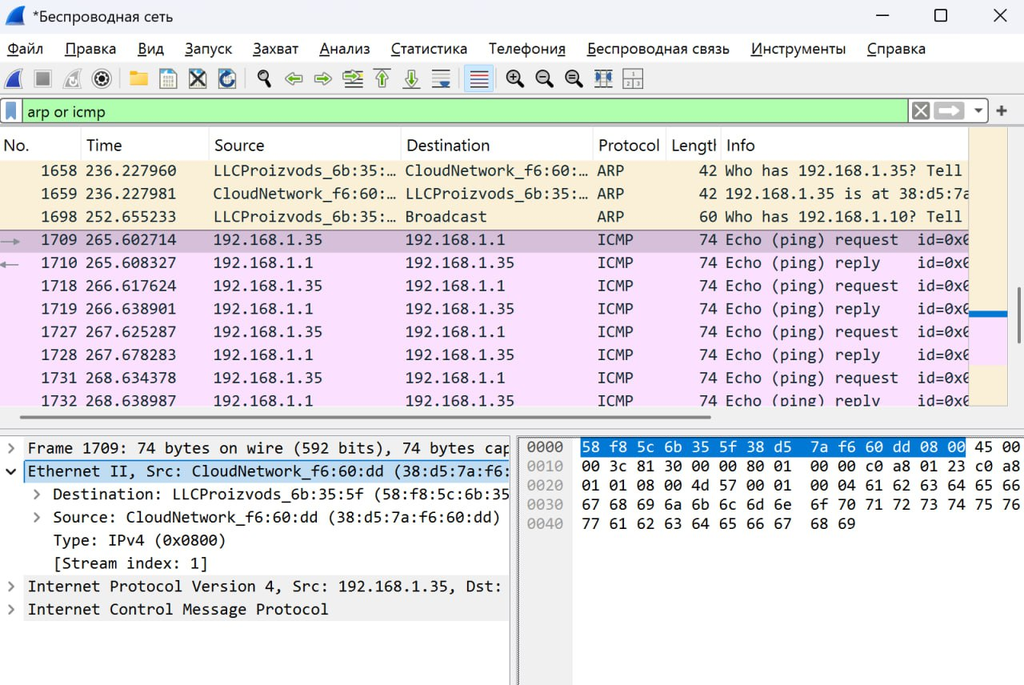

Эхо-запрос

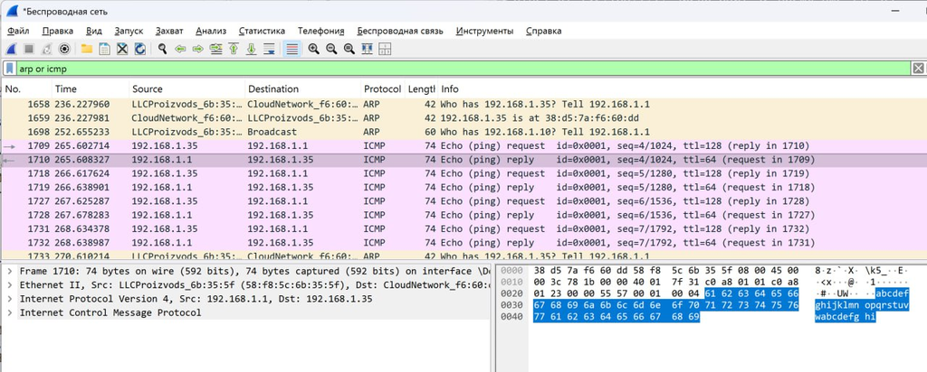

Эхо-ответ

## Протокол ARP

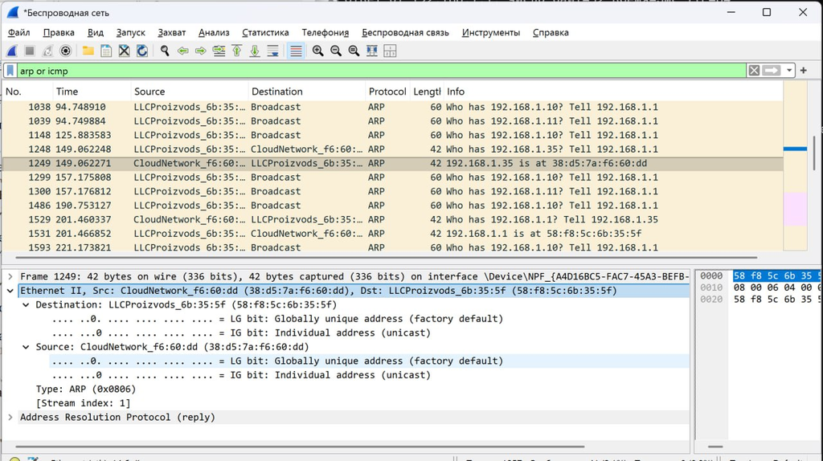

Кадры протокола ARP

## Просмотр данных

Начнем новый процесс захвата и пропингуем любой другой адрес, например, VK

При обмене пакетами с внешними сетями MAC-адреса источника и назначения в кадре Ethernet всегда принадлежат устройствам локальной сети (отправителю и шлюзу).

## Просмотр данных

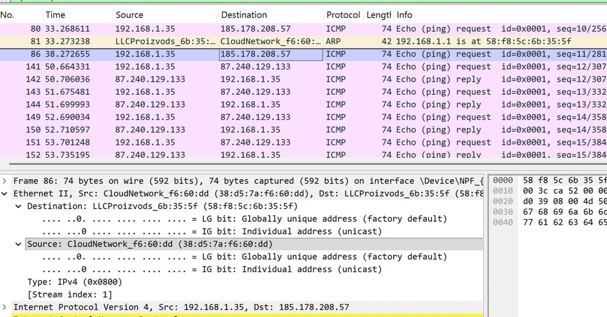

Запрос

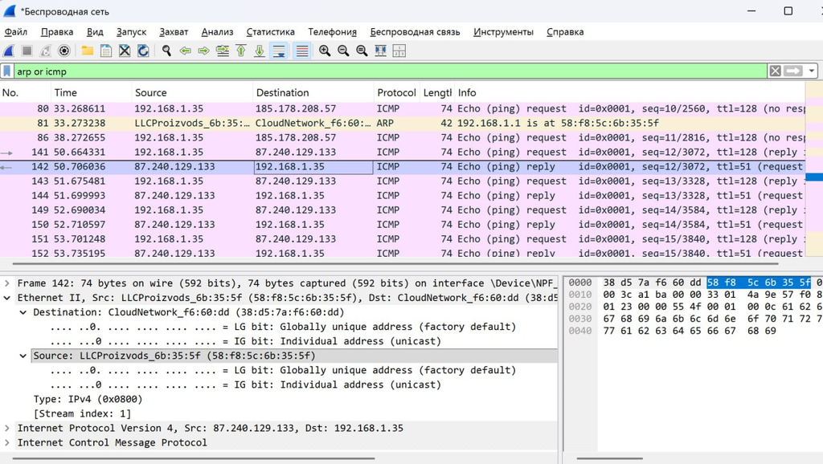

Ответ

## Анализ протоколов транспортного уровня

Для QUIC запросов используется UDP протокол, ipv6, видны типы пактов - initial(c основными данными), handshake.

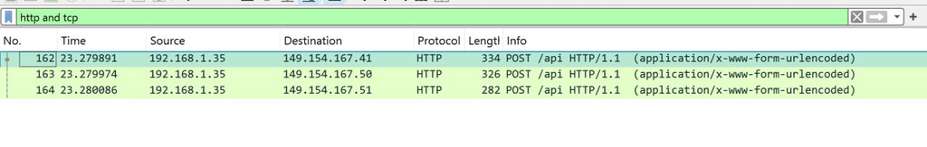

HTTP

## Анализ протоколов транспортного уровня

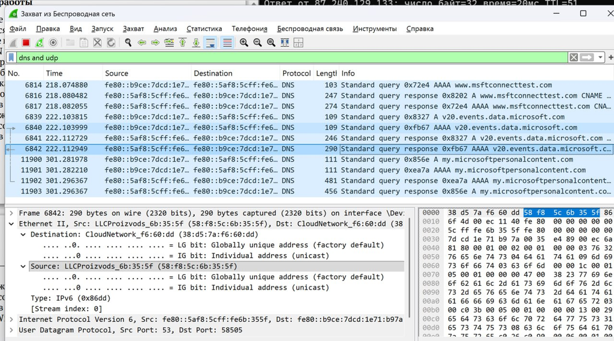

DNS

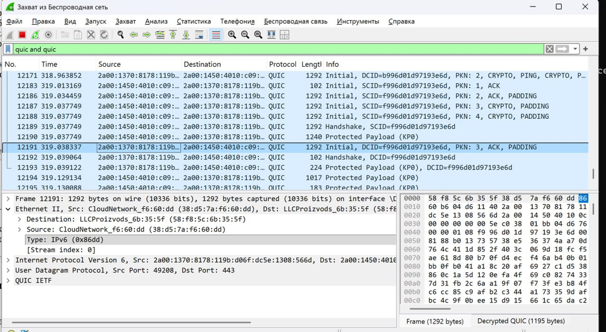

QUIC

## Handshake

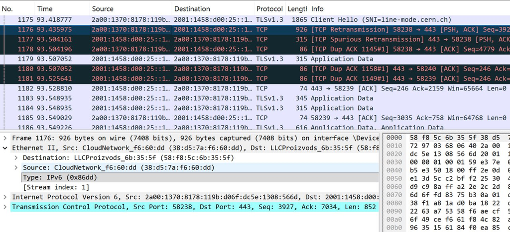

Просмотр перехвата

TCP Handshake (3-way):

Клиент → Сервер: SYN (запрос на соединение)

Сервер → Клиент: SYN-ACK (подтверждение + свой запрос)

Клиент → Сервер: ACK (подтверждение). Соединение установлено.

## График потока

Далее просмотрим график потока в меню статистика и ознакомимся с информацией. Остановим захват.

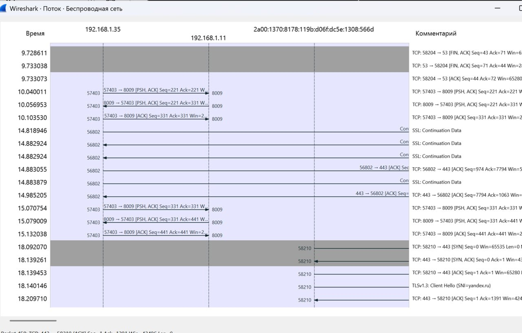

График потока

# Вывод

## Выводы

- В ходе работы было произведено знакомство с Wireshark, были изучены с его помощью кадры Ethernet, произведенр анализ PDU протоколов транспортного и прикладного уровней стека TCP/IP